# E exp 3

Matt Green

```r
dat_full <- preprocessing(root_dir, data_dir)
dat <- subset(dat_full, RT>0 & RT<9500)
dat_borderline <- dat
dat <- perSubjectTrim.fnc(dat, response='RT', subject='Subject', trim = 2.5)$data
```

```
## ......
## n.removed = 211
## percent.removed = 2.750619
```

```r
dat$RT_log <- log(dat$RT)
```

# Info and Procedure (Method)

The distinctive thing in this experiment is that in order to avoid mentioning a number, we had to show a “Target” (similar to a prime) that presented an array with a certain number of dots which we could later refer to as “the target” in expressions like “the same number of dots as the target”.

RTs were overwhelmingly faster in this experiment than in experiments where numbers were used in the instructions.

Each subject saw 192 trials, being 3 cycles of 64 trials. There were 40 subjects. There were 7680 rows in the full data.

First an instruction was presented until subjects dismissed it with a key press. Then a grey screen was presented for 1 second. Then a prime was presented for 2 seconds. Then a grey screen was presented for 1 second. Then the squares with dots were presented until the subject responded, with a 10 second timeout if they did not respond.

# Sample display

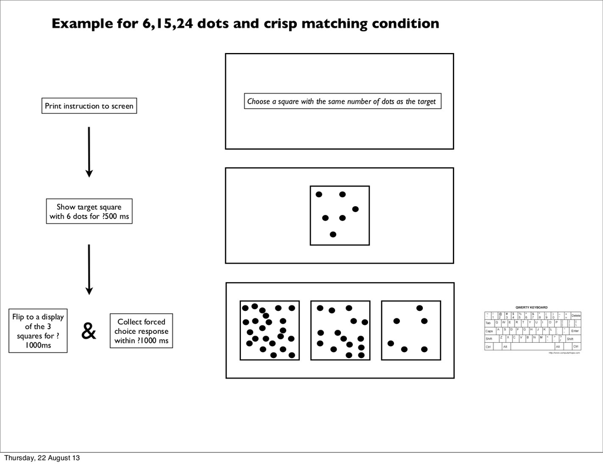

Flow of experiment E_exp_3.

# Full table of instructions

Full table of instructions

| Item | Target | Quantity | Selection | Crisp | Vague |
| --- | --- | --- | --- | --- | --- |
| 06:15:24 | 6 | Small | Matching | Choose a square with the same number of dots as the target | NA |
| 06:15:24 | 10 | Small | Matching | NA | Choose a square with about the same number of dots as the target |
| 06:15:24 | 10 | Large | Comparison | Choose a square with more dots than the target | Choose a square with far more dots than the target |
| 06:15:24 | 20 | Small | Comparison | Choose a square with fewer dots than the target | Choose a square with far fewer dots than the target |
| 06:15:24 | 20 | Large | Matching | NA | Choose a square with about the same number of dots as the target |
| 06:15:24 | 24 | Large | Matching | Choose a square with the same number of dots as the target | NA |
| 16:25:34 | 16 | Small | Matching | Choose a square with the same number of dots as the target | NA |
| 16:25:34 | 20 | Small | Matching | NA | Choose a square with about the same number of dots as the target |
| 16:25:34 | 20 | Large | Comparison | Choose a square with more dots than the target | Choose a square with far more dots than the target |
| 16:25:34 | 30 | Small | Comparison | Choose a square with fewer dots than the target | Choose a square with far fewer dots than the target |
| 16:25:34 | 30 | Large | Matching | NA | Choose a square with about the same number of dots as the target |
| 16:25:34 | 34 | Large | Matching | Choose a square with the same number of dots as the target | NA |
| 26:35:44 | 26 | Small | Matching | Choose a square with the same number of dots as the target | NA |
| 26:35:44 | 30 | Small | Matching | NA | Choose a square with about the same number of dots as the target |
| 26:35:44 | 30 | Large | Comparison | Choose a square with more dots than the target | Choose a square with far more dots than the target |
| 26:35:44 | 40 | Small | Comparison | Choose a square with fewer dots than the target | Choose a square with far fewer dots than the target |
| 26:35:44 | 40 | Large | Matching | NA | Choose a square with about the same number of dots as the target |
| 26:35:44 | 44 | Large | Matching | Choose a square with the same number of dots as the target | NA |
| 36:45:54 | 36 | Small | Matching | Choose a square with the same number of dots as the target | NA |
| 36:45:54 | 40 | Small | Matching | NA | Choose a square with about the same number of dots as the target |
| 36:45:54 | 40 | Large | Comparison | Choose a square with more dots than the target | Choose a square with far more dots than the target |
| 36:45:54 | 50 | Small | Comparison | Choose a square with fewer dots than the target | Choose a square with far fewer dots than the target |
| 36:45:54 | 50 | Large | Matching | NA | Choose a square with about the same number of dots as the target |
| 36:45:54 | 54 | Large | Matching | Choose a square with the same number of dots as the target | NA |

# Means plots

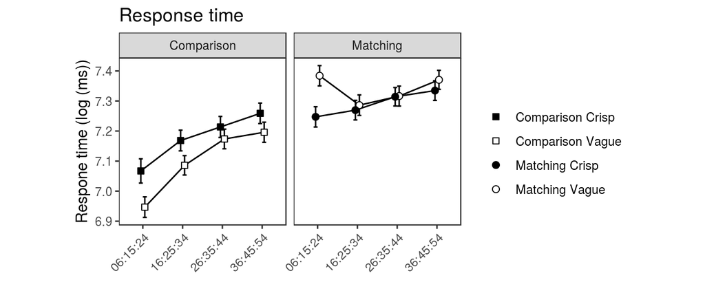

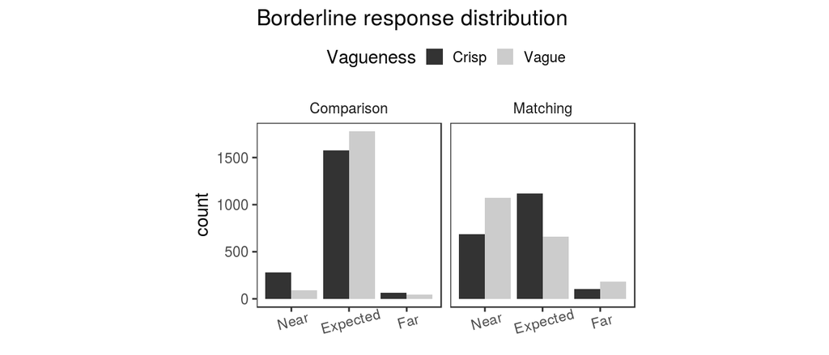

# Hypotheses

We formulated the following hypotheses:

- [Hypothesis 1] Crisp/Vague RT:
  - Vague instructions should result in faster responses than crisp instructions.
- [Hypothesis 2] Comparison/Matching RT:
  - Instructions that allow comparison should result in faster responses than instructions that necessitate matching.
- [Hypothesis 3] Vagueness effect differs between comparison and matching:
  - The effects of vagueness should differ when the selection task is comparison versus when it is matching.

# Results

An initial observation is that response times were much faster than in our previous experiments. It seems that when there are no numbers in the instructions, and the instructions refer to a previously-seen trial-initial array, participants are able to resolve those instructions an order of magnitude more quickly than when the instructions use numbers, and make no reference to any previously-seen trial-initial array.

Response times were trimmed at 9,500 ms, resulting in the loss of 9 trials that were judged to have outlier RTs. The remaining data were trimmed separately for each participant at 2.5 standard deviations below and above that participant’s mean RT, leading to the loss of 211 trials (2.8% of the remaining trials). RTs in milliseconds were log-transformed so that they better approximated a normal distribution for the purposes of analysis.

## The first set of models

```r
dat_model <- dat
dat_model$c_Vag <- ifelse(dat_model$Vagueness=="Crisp", -0.5, 0.5)
dat_model$c_Sel <- ifelse(dat_model$Selection=="Comparison", -0.5, 0.5)
dat_model$c_Itm <- ifelse(dat_model$Item=="06:15:24", -.75, ifelse(dat_model$Item=="16:25:34", -.25, ifelse(dat_model$Item=="26:35:44", .25, .75)))
rtlmer = lmerTest::lmer(data=dat_model, RT_log ~ c_Vag * c_Sel + c_Itm + (1 + c_Vag * c_Sel + c_Itm | Subject))
pretty_coef_table(rtlmer, "rt_lmer_full_model_all_items")
```

rt_lmer_full_model_all_items

| term | 𝛽 | s.e. | d.f. | 𝑡 | 𝑝 | Pr(>\|t\|) | sig. |
| --- | --- | --- | --- | --- | --- | --- | --- |
| c_Vag | -0.015 | 0.0099 | 58.99 | -1.54 | 1.30e-01 | 0.13 |  |
| c_Sel | 0.176 | 0.0170 | 39.02 | 10.39 | 8.62e-13 | <0.001 | ＊＊＊ |
| c_Itm | 0.089 | 0.0097 | 42.12 | 9.12 | 1.59e-11 | <0.001 | ＊＊＊ |
| c_Vag:c_Sel | 0.123 | 0.0242 | 40.01 | 5.10 | 8.69e-06 | <0.001 | ＊＊＊ |

```r
dat_model <- subset(dat, subset=Selection=='Comparison')
dat_model$c_Vag <- ifelse(dat_model$Vagueness=="Crisp", -0.5, 0.5)
dat_model$c_Itm <- ifelse(dat_model$Item=="06:15:24", -.75, ifelse(dat_model$Item=="16:25:34", -.25, ifelse(dat_model$Item=="26:35:44", .25, .75)))
comp_lmer <- lmerTest::lmer(data=dat_model, RT_log ~ c_Vag + c_Itm + (1 + c_Vag + c_Itm | Subject))
pretty_coef_table(comp_lmer, "rt_lmer_for_comparison_all_items")
```

rt_lmer_for_comparison_all_items

| term | 𝛽 | s.e. | d.f. | 𝑡 | 𝑝 | Pr(>\|t\|) | sig. |
| --- | --- | --- | --- | --- | --- | --- | --- |
| c_Vag | -0.077 | 0.018 | 39.18 | -4.31 | 1.08e-04 | <0.001 | ＊＊＊ |
| c_Itm | 0.145 | 0.015 | 38.95 | 9.65 | 7.06e-12 | <0.001 | ＊＊＊ |

```r
dat_model <- subset(dat, subset=Selection=='Matching')
dat_model$c_Vag <- ifelse(dat_model$Vagueness=="Crisp", -0.5, 0.5)
dat_model$c_Itm <- ifelse(dat_model$Item=="06:15:24", -.75, ifelse(dat_model$Item=="16:25:34", -.25, ifelse(dat_model$Item=="26:35:44", .25, .75)))
match_lmer <- lmerTest::lmer(data=dat_model, RT_log ~ c_Vag + c_Itm + (1 + c_Vag + c_Itm | Subject))
pretty_coef_table(match_lmer, "rt_lmer_for_matching_all_items")
```

rt_lmer_for_matching_all_items

| term | 𝛽 | s.e. | d.f. | 𝑡 | 𝑝 | Pr(>\|t\|) | sig. |
| --- | --- | --- | --- | --- | --- | --- | --- |
| c_Vag | 0.047 | 0.013 | 61.08 | 3.71 | 4.46e-04 | <0.001 | ＊＊＊ |
| c_Itm | 0.031 | 0.012 | 57.61 | 2.55 | 1.33e-02 | <0.05 | ＊ |

Considering the first set of models:

- [Hypothesis 1] Crisp/Vague RT:
  - *Vague instructions should result in faster responses than crisp instructions* : Vague instructions resulted in faster responses than crisp instructions, but this effect was very small and not significant (p=0.13)
- [Hypothesis 2] Comparison/Matching RT:
  - *Instructions that allow comparison should result in faster responses than instructions that necessitate matching* : Comparison instructions resulted in faster responses than matching and this difference was significant (p<0.001)
- [Hypothesis 3] Vagueness effect differs between comparison and matching:
  - *The effects of vagueness should differ when the selection task is comparison versus when it is matching* : Vague instructions did have different effects depending on whether the selection task is comprison or matching (p<0.001). In the comparison condition vague instructions resulted in significantly faster responses (p<0.001). In the selection condition vague instructions slowed down responses significantly (p<0.001)

## The second set of models

The second set of models considered were conducted to test for main effects *in the presence of interactions involving those main effects* (after Levy, 2018).

The variables are: Vagueness 2 levels (X) Item 4 levels (Y) Selection 2 levels (Z)

```r
dat_model <- dat
dat_model$c_Vag <- ifelse(dat_model$Vagueness=="Crisp", -0.5, 0.5)
dat_model$c_Sel <- ifelse(dat_model$Selection=="Comparison", -0.5, 0.5)
dat_model$c_Itm <- ifelse(dat_model$Item=="06:15:24", -.75, ifelse(dat_model$Item=="16:25:34", -.25, ifelse(dat_model$Item=="26:35:44", .25, .75)))

Item.numeric <- sapply(dat_model$Item,function(i) contr.sum(4)[i,])
dat_model$Item1 <- Item.numeric[1,]
dat_model$Item2 <- Item.numeric[2,]
dat_model$Item3 <- Item.numeric[3,]
```

```r
null.model2 <- lmer(RT_log ~
                     c_Sel + c_Vag:c_Sel + # main effect of selection and the interaction with vagueness
                     Item1 + c_Vag:Item1 +         # item effect and interaction with vagueness
                     Item2 + c_Vag:Item2 +         # item effect and interaction with vagueness
                     Item3 + c_Vag:Item3 +         # item effect and interaction with vagueness
                     (c_Sel + c_Vag + c_Itm| Subject), # per-subject
                   dat_model, REML=FALSE)
```

```r
pretty_coef_table(null.model2, "null.model2")
```

null.model2

| term | 𝛽 | s.e. | d.f. | 𝑡 | 𝑝 | Pr(>\|t\|) | sig. |
| --- | --- | --- | --- | --- | --- | --- | --- |
| c_Sel | 0.181 | 0.0165 | 40.02 | 11.00 | 1.16e-13 | <0.001 | ＊＊＊ |
| Item1 | -0.069 | 0.0085 | 95.96 | -8.06 | 2.15e-12 | <0.001 | ＊＊＊ |
| Item2 | -0.025 | 0.0073 | 2852.61 | -3.36 | 7.89e-04 | <0.001 | ＊＊＊ |
| Item3 | 0.028 | 0.0074 | 2862.55 | 3.86 | 1.14e-04 | <0.001 | ＊＊＊ |
| c_Sel:c_Vag | 0.124 | 0.0166 | 7342.13 | 7.43 | 1.17e-13 | <0.001 | ＊＊＊ |
| c_Vag:Item1 | 0.019 | 0.0144 | 7341.47 | 1.34 | 1.81e-01 | 0.181 |  |
| c_Vag:Item2 | -0.018 | 0.0144 | 7341.11 | -1.25 | 2.10e-01 | 0.21 |  |
| c_Vag:Item3 | -0.003 | 0.0144 | 7340.32 | -0.21 | 8.36e-01 | 0.836 |  |

```r
full.model2 <- lmer(RT_log ~
                     c_Vag +
                     c_Sel + c_Vag:c_Sel + # main effect of selection and the interaction with vagueness
                     Item1 + c_Vag:Item1 +         # item effect and interaction with vagueness
                     Item2 + c_Vag:Item2 +         # item effect and interaction with vagueness
                     Item3 + c_Vag:Item3 +         # item effect and interaction with vagueness
                     (c_Sel + c_Vag + c_Itm| Subject), # per-subject
                   dat_model, REML=FALSE)
```

```r
pretty_coef_table(full.model2, "full.model2")
```

full.model2

| term | 𝛽 | s.e. | d.f. | 𝑡 | 𝑝 | Pr(>\|t\|) | sig. |
| --- | --- | --- | --- | --- | --- | --- | --- |
| c_Vag | -0.015 | 0.0097 | 58.90 | -1.58 | 1.19e-01 | 0.119 |  |
| c_Sel | 0.176 | 0.0168 | 40.03 | 10.51 | 4.50e-13 | <0.001 | ＊＊＊ |
| Item1 | -0.067 | 0.0086 | 87.87 | -7.83 | 1.02e-11 | <0.001 | ＊＊＊ |
| Item2 | -0.024 | 0.0073 | 2655.32 | -3.28 | 1.05e-03 | <0.01 | ＊＊ |
| Item3 | 0.028 | 0.0074 | 2670.53 | 3.79 | 1.55e-04 | <0.001 | ＊＊＊ |
| c_Vag:c_Sel | 0.123 | 0.0166 | 7342.67 | 7.42 | 1.29e-13 | <0.001 | ＊＊＊ |
| c_Vag:Item1 | 0.019 | 0.0144 | 7342.80 | 1.33 | 1.82e-01 | 0.182 |  |
| c_Vag:Item2 | -0.018 | 0.0144 | 7342.23 | -1.25 | 2.12e-01 | 0.212 |  |
| c_Vag:Item3 | -0.003 | 0.0144 | 7341.50 | -0.21 | 8.36e-01 | 0.836 |  |

```r
anova(null.model2, full.model2)
```

```
## Data: dat_model
## Models:
## null.model2: RT_log ~ c_Sel + c_Vag:c_Sel + Item1 + c_Vag:Item1 + Item2 +
## null.model2:     c_Vag:Item2 + Item3 + c_Vag:Item3 + (c_Sel + c_Vag + c_Itm |
## null.model2:     Subject)
## full.model2: RT_log ~ c_Vag + c_Sel + c_Vag:c_Sel + Item1 + c_Vag:Item1 +
## full.model2:     Item2 + c_Vag:Item2 + Item3 + c_Vag:Item3 + (c_Sel + c_Vag +
## full.model2:     c_Itm | Subject)
##             Df    AIC    BIC  logLik deviance  Chisq Chi Df Pr(>Chisq)
## null.model2 20 6195.5 6333.8 -3077.8   6155.5
## full.model2 21 6195.0 6340.3 -3076.5   6153.0 2.4443      1      0.118
```

- [Hypothesis 1] Crisp/Vague RT:
  - *Vague instructions should result in faster responses than crisp instructions* : Vague instructions resulted in faster responses than crisp instructions on average (beta = -0.015 units of log(ms)). However this difference was not significant in the full model (p=0.119). Using Levy’s method to test for main effects in the presence of higher-order interactions, by doing model comparison between a null model that included all interaction terms involving Vagueness but leaving out a term for the main effect of Vagueness, against a full model that differed only by including Vagueness as a main effect, showed that the full model was no better than the reduced model (df=1, p=0.118) - consituting more evidence that Vagueness did not exert a significant main effect on response times.
- [Hypothesis 2] Comparison/Matching RT:
  - *Instructions that allow comparison should result in faster responses than instructions that necessitate matching* : comparison instructions resulted in faster responses than matching instructions, and the difference was significant (beta=0.176, p<0.001).
- [Hypothesis 3] Vagueness effect differs between comparison and matching:
  - *The effects of vagueness should differ when the selection task is comparison versus when it is matching* : Vagueness did not exert a significant main effect, Vagueness did exert effects in interactions with some other variables: the interaction between Vagueness and Selection task was significant (beta=0.123, p<0.001), suggesting that Vagueness speeded RTs in the comparison condition but slowed them down in the matching task. Separate analyses at each level of selection provided evidence that vague instructions resulted in faster responses than crisp instructions for the comparison condition (p<0.01); and slower responses than crisp instructions in the matching condition (p<0.01).